**I Don't Air**

# Plane Crashes: An Analysis on Fatalities

Whenever a plane crashes it is always on the news. The fear of flying is so common that even people who aren't afraid of flying get worried whenever strong turbulance hits. Despite not being common it is commonly shown in media, through shows, movies, and books to build build plot and setting. But in real life the first information people want to know about is how many fatalities there were. So the question is how fatal are plane crashes and have improvements made flying safer. Let's take a look at the planes crashes from 2000 - 2021 and see if flying has gotten safer over the years and are there any trends we can learn from?

First, we need some methods for scraping the data from http://www.planecrashinfo.com/database.htm

First we scrape the data. We take the table and take all the elements to create our observations. We want to separate some of the data. For example, some observations have a date but not a time.

- date : date the plane crashed
- year : year the plane crashed
- timePlane : time the plane crashed
- city : city the plane crashed
- country : country the plane crashed
- operator : airline for the plane, includes military operators
- flightNum : flight number of the plane
- depart : departure city
- arrive : arrival city
- ACType : air craft type
- registration : registration
- certificationNum : certification number
- passengersAboard : number of passengers on board
- crewAboard : number of crew on board
- passengersDeath : number of passengers who died
- crewDeath : number of crew who died
- groundDeath : number of people who died not aboard the aircraft
- summary : summary of what happened upto and during the crash The database also includes a summary about how the plane crashed. If the summary contains certain words we can then infer the cause of the crash. For example, if the summary contains words pertaining to weather(storms, fog, visibility), we know that weather caused or partially caused the crash. This method of obtaining crash causes is not perfect, we found the classifying words by manually looking through summaries and selecting words or predicting good words.

Our crash cause categories include:

- weather : weather based accidents
- mechanical : mechanical failures in the plane
- conflict : intentional damage or control taken from the plane, such as sabotage or hijacking
- terrain : damage caused by the surrounding terrain
- accident : malpractice when flying the aircraft

```python
import pandas as pd
import numpy as np
import matplotlib.pyplot as plt
import requests
from bs4 import BeautifulSoup
import regex as re
from urllib.parse import urljoin
import time
from datetime import datetime

#res = requests.get("http://www.planecrashinfo.com/database.htm")

#soup = BeautifulSoup(res.content, 'html.parser')

website = "http://www.planecrashinfo.com/"

# url for each year
# for url in soup.find_all('a', href=True):
#   print(url["href"].split("/")[1])
    # if (url['href'] != "/index/htm" and int(url["href"].split()[0]) >= 2000):
    #   #print ("Found the URL:", url['href'])
    #   yearRes = requests.get(website + url['href'])
    #   soup = BeautifulSoup(yearRes.content, 'html.parser')
    #   html = soup.find("table").prettify()
    #   print(html)

def make_soup(url):
  time.sleep(.6)
  r = requests.get(url)
  soup = BeautifulSoup(r.text, 'html.parser')
  return soup

# get all links that are for the years 2000s
def get_links(url):
    soup = make_soup(url)
    a_tags = soup.find_all('a', href=re.compile(r"2\d\d\d"))
    links = [urljoin(url, a['href'])for a in a_tags]  # convert relative url to absolute url
    return links

def get_tds(link):
    soup = make_soup(link)
    tds = soup.find_all('tr')
    if tds is not None:
      info = []
      for td in tds:
        info.append(td.text)

def get_txt(link):
    soup = make_soup(link)
    tds = soup.find_all('td')
    if tds is not None:
      info = []
      for td in tds:
        info.append(td.text)

urls = []
date = []
year = []
timePlane = []
city = []
country = []
operator = []
flightNum = []
depart = []
arrive = []
ACType = []
registration = []
certificationNum = []
passengersAboard = []
crewAboard = []
passengersDeath = []
crewDeath = []
groundDeath = []
summary = []
weather = []
mechanical = []
conflict = []
terrain = []
accident = []
weatherCause = ['wind' ,'rain', 'weather', 'lightning', 'visibility', 'fog', 'hail', 'snow', 'typhoon', 'hurricane', 'storm']
mechanicalCause = ['engine', 'fail', 'pressure', 'fire', 'flame']
conflictCause = ['shot', 'hijack', 'deliberate', 'sabotage', 'homemade', 'improvised', 'missle']
terrainCause = ['mountain', 'cliff', 'slope', 'tree', 'forest', 'Mt.', 'powerline']
accidentCause = ['accident', 'mistake', 'prerequisite', 'disorient', 'disregard', 'procedure', 'checklist']

def containsCause(summary, causes):
  for i in causes:
    if i in summary:
      return True
  return False
```

Now we can start scraping the website. Once we scrape the website, we need to clean it up as we have some missing data. We fill any missing times with pd.NaT and other missing values with pd.NA and some with None.

```python
frame = pd.DataFrame({
'date':date,
'year':year,
'time':timePlane,
'city':city,
'country':country,
'operator':operator,
'flightNum':flightNum,
'depart':depart,
'arrive':arrive,
'ACType':ACType,
'registration':registration,
'certificationNum':certificationNum,
'passengersAboard':passengersAboard,
'crewAboard':crewAboard,
'passengersDeath':passengersDeath,
'crewDeath':crewDeath,
'groundDeath':groundDeath,
'summary':summary,
'weather':weather,
'mechanical':mechanical,
'conflict':conflict,
'terrain':terrain,
'accident':accident
})
# save into dataframe
frame.to_csv('planeCrash.csv')
```

```python
for i in range(22):
  urls.append(website + f"/{2000 + i}/{2000 + i}.htm")

us_states = ['Alabama', 'Alaska', 'Arizona', 'Arkansas', 'California', 'Colorado', 'Connecticut', 'Washington DC', 'Delaware', 'Florida', 'Georgia', 'Hawaii', 'Idaho', 'Illinois', 'Indiana', 'Iowa', 'Kansas', 'Kentucky', 'Louisiana', 'Maine', 'Maryland', 'Massachusetts', 'Michigan', 'Minnesota', 'Mississippi', 'Missouri', 'Montana', 'Nebraska', 'Nevada', 'New Hampshire', 'New Jersey', 'New Mexico', 'New York', 'North Carolina', 'North Dakota', 'Ohio', 'Oklahoma', 'Oregon', 'Pennsylvania', 'Rhode Island', 'South Carolina', 'South Dakota', 'Tennessee', 'Texas', 'Utah', 'Vermont', 'Virginia', 'Washington', 'West Virginia', 'Wisconsin', 'Wyoming']

for i in range(22):
  plane = get_links(urls[i])
  time.sleep(1)
  for p in plane:
    time.sleep(1)
    data = pd.read_html(p)[0][1]

    date.append(datetime.strptime(data[1], '%B %d, %Y') if '?' not in data[1] else pd.NaT)
    if date[-1] != pd.NaT:
      year.append(date[-1].year)
    data[2] = ''.join(filter(str.isdigit, data[2]))
    # add back ? if places becomes None
    if not data[2]:
      data[2] = '?'

    timePlane.append(datetime.strptime(data[2], '%H%M') if '?' not in data[2] else pd.NaT)
    loc = data[3].split(', ')
    if len(loc) == 1:
      loc = data[3].split(' ,')
      if len(loc) == 1:
        loc = [loc[0], loc[0]] # for manicupality
    city.append(loc[0])

    if loc[1] in us_states: # places in USA have state instead of country name
          country.append('United States of America')
    else:
      country.append(loc[1])
    operator.append(data[4])

    flightNum.append(data[5] if '?' not in data[5] else pd.NA)
    depArr = data[6].split(' - ')

    # some places have route as 'Sightseeing'
    if len(depArr) == 1:
      arrive.append(depArr[0])
    else:
      arrive.append(depArr[1])
    depart.append(depArr[0])
    ACType.append(data[7])
    registration.append(data[8])
    certificationNum.append(data[9])

    m = re.search('passengers:(\d+) crew:(\d+)', data[10])
    if m:
      passengersAboard.append(int(m.group(1)))
      crewAboard.append(int(m.group(2)))
    else:
      passengersAboard.append(pd.NA)
      crewAboard.append(pd.NA)

    m = re.search('passengers:(\d+) crew:(\d+)', data[11])
    if m:
      passengersDeath.append(int(m.group(1)))
      crewDeath.append(int(m.group(2)))
    else:
      passengersDeath.append(pd.NA)
      crewDeath.append(pd.NA)

    if data[12] == '?':
      groundDeath.append(pd.NA)
    else:
      groundDeath.append(int(data[12]))

    summary.append(data[13])

    weather.append(containsCause(data[13], weatherCause))
    mechanical.append(containsCause(data[13], mechanicalCause))
    conflict.append(containsCause(data[13], conflictCause))
    terrain.append(containsCause(data[13], terrainCause))
    accident.append(containsCause(data[13], accidentCause))
```

```python
print('weather: ', np.sum(frame['weather']))
print('mechanical: ', np.sum(frame['mechanical']))
print('conflict: ', np.sum(frame['conflict']))
print('terrain: ', np.sum(frame['terrain']))
print('accidents: ', np.sum(frame['accident']))
print('total: ', len(frame))
```

```
weather:  297
mechanical:  314
conflict:  28
terrain:  160
accidents:  182
total:  745
```

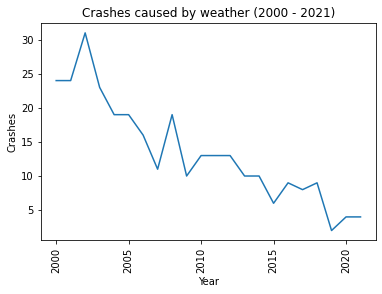

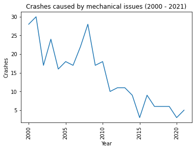

```python
frameCauses = frame.groupby(['year', 'weather'])
weatherDeath = []

for i in frameCauses['passengersDeath']:
  if i[0][1]:
    weatherDeath.append(len(i[1]))

frameCauses = frame.groupby(['year', 'mechanical'])
mechanicalDeath = []
for i in frameCauses['passengersDeath']:
  if i[0][1]:
    mechanicalDeath.append(len(i[1]))

x = list(range(2000, 2022))
plt.plot(x, weatherDeath)
plt.xticks(rotation =  'vertical')
plt.title("Crashes caused by weather (2000 - 2021)")
plt.xlabel('Year')
plt.ylabel("Crashes")
plt.show()
plt.plot(x, mechanicalDeath)
plt.xticks(rotation =  'vertical')
plt.title("Crashes caused by mechanical issues (2000 - 2021)")
plt.xlabel('Year')
plt.ylabel("Crashes")
plt.show()
```

Overall we can see that crashes caused by weather or mechanical issues have gone down throughout the years. So there doesn't seem to be one reason that makes plane crashes happen. We can see that both of these caueses have gone done in recent years which could mean planes have gotten better and handeling these situations.

```python
groupAirline = frame.groupby(['operator'])
totalDeaths = []
for i in groupAirline['passengersDeath']:
  totalDeaths.append((np.sum(i[1]), i[0]))

totalDeaths = sorted(totalDeaths, reverse = True)
```

We want to see if there are any trends in the total number of fatalities across the years of the data we gathered. We can do that by plotting a frequency bar graph of the number of deaths per year. Let's look at if the operator of the plane tells us anything, are there airlines that are more dangerous than others?

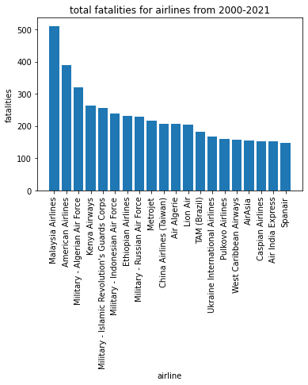

```python
x, y = zip(*totalDeaths[:20])

plt.bar(y, x)
plt.xticks(np.arange(len(x)), y, rotation =  'vertical')
plt.title('total fatalities for airlines from 2000-2021')
plt.xlabel('airline')
plt.ylabel('fatalities')
plt.show()
```

We can see that there are two that are higher than all other airlines, Malaysia Airlines and American Airlines. But when we think proportionally of how many people fly these airlines overall, there isn't an airline that would standout as being more dangerous. None of these airlines even reach death tolls of 1,000. What is more interesting is that in the top 20 are military forces. Let's come back to this later...

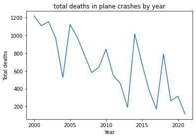

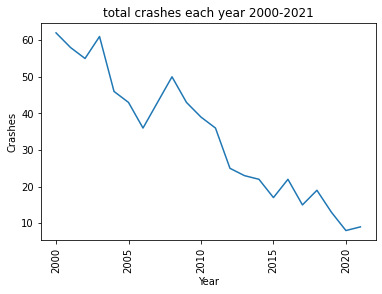

```python
groupYear = frame.groupby(['year'])
totalDeathsYear = []
proportionDeaths = []
for d, a in zip(groupYear['passengersDeath'], groupYear['passengersAboard']):
  totalDeathsYear.append((np.sum(d[1]), d[0]))
  aboard = 1 if np.sum(a[1]) == 0 else np.sum(a[1])
  deaths = 0 if np.sum(a[1]) == 0 else np.sum(d[1])

  proportionDeaths.append((deaths/aboard, d[0]))
x, y = zip(*totalDeathsYear)
plt.plot(y, x)
plt.title('total deaths in plane crashes by year')
plt.ylabel('Total deaths')
plt.xlabel('Year')
plt.show()


crashes = []
frameCountry = frame.groupby(['year'])
years = list(range(2000,2022))
for i in frameCountry['passengersDeath']:
  crashes.append(len(i[1]))

plt.plot(years, crashes)
plt.xticks(rotation = 'vertical')
plt.title('total crashes each year 2000-2021')
plt.xlabel('Year')
plt.ylabel('Crashes')
plt.show()
```

As we can see from the graph, there is an overall downward trend of total deaths in plane crashes per year. Although there are spikes due to tragic accidents, the overall trend is negative. We can attribute this to a multitude of things, such as:

- The introduction of the Pilot Fatigue Rule (https://www.cnn.com/2011/12/21/travel/pilot-fatigue-rule/index.html#)
- Mandating Locked cockpit doors after 9/11 (https://www.bbc.com/news/blogs-magazine-monitor-32070528)
- GPS Systems improving (https://airandspace.si.edu/stories/editorial/twenty-years-gps-and-instrument-flight)

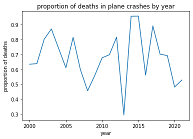

```python
x, y = zip(*proportionDeaths)
plt.plot(y, x)
plt.title('proportion of deaths in plane crashes by year')
plt.ylabel('proportion of deaths')
plt.xlabel('year')
plt.show()
```

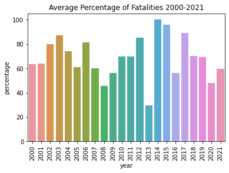

```python
import seaborn as sns
avgPassenger = frame.groupby('year')['passengersAboard'].mean().reset_index()
avgDeaths = frame.groupby('year')['passengersDeath'].mean().reset_index()
avg= avgPassenger.copy()
avg['avgDeaths'] = avgDeaths['passengersDeath']
avg = avg.rename(columns={'passengersAboard': 'avgPassengers'})
avg['percentage'] = (avg['avgDeaths'] / avg['avgPassengers']) * 100
plt.xticks(rotation=90)
ax = sns.barplot(x="year", y="percentage", data=avg).set(title='Average Percentage of Fatalities 2000-2021')
```

Although the amount of crashes have gone throughout the years we can see with both visualizations that these crashes aren't getting any less fatal. There is no trend with plane crash survivability. Maybe it has to do with where these planes are crashing? Let's figureout the coordinates of these crashes and see if we can find a trend.

```python
from geopy.geocoders import Nominatim

geolocator = Nominatim(user_agent="my_user_agent", timeout = 5)

location = []
for row in frame.itertuples():
  city = row[3]

  if "Near" in row[3]:
    city = row[3].replace("Near ", "")

  if "Off" in row[3]:
    city = row[3].replace("Off ", "")

  place = f"{city}, {row[4]}"
  loc = geolocator.geocode(place)
  if loc:
    location.append((loc.latitude, loc.longitude))
  else:
    # couldn't find location, approximate to just country
    loc = geolocator.geocode(row[4])
    if loc:
      location.append((loc.latitude, loc.longitude))
    else:
      location.append(None)

frame.insert(loc = 1, column = "lat long", value = location)
frame.head(10)
```

[output not shown]

```python
frame.drop(frame[pd.isna(frame['lat long'])].index, inplace = True)
```

Let's drop the crashes where we couldn't find the location because we won't be able to plot this and giving these places filler locations will be misleading.

```python
frameCountry = frame.groupby(['country'])
countryDeaths = []
for i in frameCountry['passengersDeath']:
  countryDeaths.append((np.sum(i[1]), i[0]))

countryDeaths = sorted(countryDeaths, reverse = True)
```

Looking at every crash will be a mess and too hard to read so let's limit our range to where most of these deaths are occuring. Which countries have the highest plane crash fatalities? Lets take a look a the countries with the top 5 fatalities.

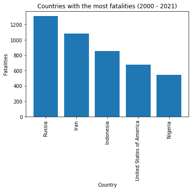

```python
x, y = zip(*countryDeaths[:5])

plt.bar(y, x)
plt.xticks(np.arange(len(x)), y, rotation =  'vertical')
plt.title("Countries with the most fatalities (2000 - 2021)")
plt.xlabel('Country')
plt.ylabel("Fatalities")
plt.show()
# We are going to map the five countries with the higest fatality count
```

The countries are Russia, Iran, Indonesia, The United States of America, and Nigeria. It is interesting how spread out these countries are across the globe. The first thing that stands out is all of these countries have a lot of landmass. With Russia ranking 1st, Iran ranking 18th, Indonesia ranking 15th, The United States ranking 4th, and Nigeria ranking 32nd. Lets Map each plane crash for each of these countries to see if there is a common trend.

```python
import folium
geolocator = Nominatim(user_agent="my_user_agent", timeout = 4)

loc1 = geolocator.geocode(y[0])

map_osm = folium.Map(location=[loc1.latitude, loc1.longitude], zoom_start=5)
```

Let's give a different color for each year and lets scale the size of a circle around the crash location based on the number of fatalities for that crash. Let's also make a distinction between flights that departed in the country (white) and those outside the country (black). Many of these countries aren't just flying cargo or passanger planes but also doing military traning. Earlier we say that some military forces accounted for many plane deaths. So, let's also make a distinction between military and non-military planes with the color of the mark: military (white) and non-military (black).

```python
def mapCrashes(mapSpot, year, lat, lon, fatal, domestic, military):
  colorMark = ['#ff3733', '#3375ff', '#33ff7c', '#8933ff', '#ffa133', '#cb4b4b', '#f29999', '#eecda9', '#0f165c', '#07610a', '#5f9ea0', '#3f0761', '#ffffff', '#f8b0e6', '#b0f2f8', '#b0f8cc', '#aeb7b2', '#000000', '#e0dbdb', '#efdf40', '#3b7d7c', '#8f81fd']
  colorBor = "#000000"
  if domestic:
    colorBor = '#ffffff'
  folium.CircleMarker(
    location=[lat, lon],
    radius= 1 * fatal,
    popup= str(year),
    color= colorBor,
    fill=True,
    fill_color=colorMark[2021 - year],).add_to(mapSpot)
  folium.Marker(location=[lat, lon],icon=folium.Icon(color = military, icon_color= colorMark[2021 - year])).add_to(mapSpot)
```

```python
map_osm = folium.Map(location=[loc1.latitude, loc1.longitude], zoom_start=4)

for index, table in frame[frame["country"] == y[0]].iterrows():
  year = table['date'].split("-")[0]
  coord = table['lat long'].replace("(", "").replace(")", "").split(", ")
  startLoc = f"{table['depart']}, {table['country']}"
  domestic = False
  military = 'black'
  if ('Military' in table['operator']):
    military = 'white'
  if geolocator.geocode(startLoc):
    domestic = True
  if table['depart'] == 'Training':
    domestic = True
  mapCrashes(map_osm, int(year), float(coord[0]), float(coord[1]), table['passengersDeath'], domestic, military)

map_osm
```

Make this Notebook Trusted to load map: File -> Trust Notebook

[interactive chart not shown]

Map of crashes in Russia above. Clicking on the radius gives the year.

```python
loc2 = geolocator.geocode(y[1])

map_osm2 = folium.Map(location=[loc2.latitude, loc2.longitude], zoom_start=6)

for index, table in frame[frame["country"] == y[1]].iterrows():
  year = table['date'].split("-")[0]
  coord = table['lat long'].replace("(", "").replace(")", "").split(", ")
  startLoc = f"{table['depart']}, {table['country']}"
  domestic = False
  if geolocator.geocode(startLoc):
    domestic = True
  if table['depart'] == 'Training':
    domestic = True
  military = 'black'
  if ('Military' in table['operator']):
    military = 'white'
  mapCrashes(map_osm2, int(year), float(coord[0]), float(coord[1]), table['passengersDeath'], domestic, military)
map_osm2
```

Make this Notebook Trusted to load map: File -> Trust Notebook

[interactive chart not shown]

Map of crashes in Iran above. Clicking on the radius gives the year.

```python
loc3 = geolocator.geocode(y[2])

map_osm3 = folium.Map(location=[loc3.latitude, loc3.longitude], zoom_start=5)

for index, table in frame[frame["country"] == y[2]].iterrows():
  year = table['date'].split("-")[0]
  coord = table['lat long'].replace("(", "").replace(")", "").split(", ")
  startLoc = f"{table['depart']}, {table['country']}"
  domestic = False
  if geolocator.geocode(startLoc):
    domestic = True
  if table['depart'] == 'Training':
    domestic = True
  military = 'black'
  if ('Military' in table['operator']):
    military = 'white'
  mapCrashes(map_osm3, int(year), float(coord[0]), float(coord[1]), table['passengersDeath'], domestic, military)
map_osm3
```

Make this Notebook Trusted to load map: File -> Trust Notebook

[interactive chart not shown]

Map of crashes in Indonesia above. Clicking on the radius gives the year.

```python
loc4 = geolocator.geocode(y[3])

map_osm4 = folium.Map(location=[loc4.latitude, loc4.longitude], zoom_start=5)

for index, table in frame[frame["country"] == y[3]].iterrows():
  year = table['date'].split("-")[0]
  coord = table['lat long'].replace("(", "").replace(")", "").split(", ")
  startLoc = f"{table['depart']}, {table['country']}"
  domestic = False
  if geolocator.geocode(startLoc):
    domestic = True
  if table['depart'] == 'Training':
    domestic = True
  military = 'black'
  if ('Military' in table['operator']):
    military = 'white'
  mapCrashes(map_osm4, int(year), float(coord[0]), float(coord[1]), table['passengersDeath'], domestic, military)
map_osm4
```

Make this Notebook Trusted to load map: File -> Trust Notebook

[interactive chart not shown]

Map of crahses in The United States above. Clicking on the radius gives the year.

```python
loc5 = geolocator.geocode(y[4])

map_osm5 = folium.Map(location=[loc5.latitude, loc5.longitude], zoom_start=5)

for index, table in frame[frame["country"] == y[4]].iterrows():
  year = table['date'].split("-")[0]
  coord = table['lat long'].replace("(", "").replace(")", "").split(", ")
  startLoc = f"{table['depart']}, {table['country']}"
  domestic = False
  if geolocator.geocode(startLoc):
    domestic = True
  if table['depart'] == 'Training':
    domestic = True
  military = 'black'
  if ('Military' in table['operator']):
    military = 'white'
  mapCrashes(map_osm5, int(year), float(coord[0]), float(coord[1]), table['passengersDeath'], domestic, military)
map_osm5
```

Make this Notebook Trusted to load map: File -> Trust Notebook

[interactive chart not shown]

Map of crashes in Nigeria above.

The first thing that is noticed is more crashes does not corolate with more fatalities. This is noticed in Iran and Nigeria which have fewer crashes when compared to Russia, Indoneisa, and The United States. But most of their crashes have a high number of fatalities. Also the majority of crashes are from planes that departed from inside the country. What is also interesting is it is not uncommon for plane crashes to be close by in location if they happened in the same year. Another thing a lot of these crashes have in common for each country is a good amount of them are near populated cities, this could mean that crashes were not too long after takeoff or when landing. The effect military crashes have on the fatality varies for each country. For places that The United States and Nigeria the military crashes don't contribute much due to their being few and the fatality being low. But for countries like Iran, Indonesia and Russia the military crash fatalities does contribute a noticable amount to their fatalities.

With this new insight, let's serperate crashes between military and non-military and see if these if the number of fatalities throughout the years will look different.

```python
military = []
def isMilitary(operator):
  if operator is None:
    return False
  elif 'Military' in operator:
    return True
  else:
    return False

for index, table in frame.iterrows():
  military.append(isMilitary(table['operator']))


frame.insert(loc = 1, column = "military", value = military)

frameCountry = frame.groupby(['year', 'military'])
milDeaths = []
nonMilDeaths = []

for i in frameCountry['passengersDeath']:
  if i[0][1]:
    milDeaths.append((np.sum(i[1]), i[0][0]))
  else:
    nonMilDeaths.append((np.sum(i[1]), i[0][0]))
```

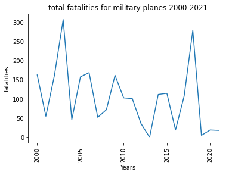

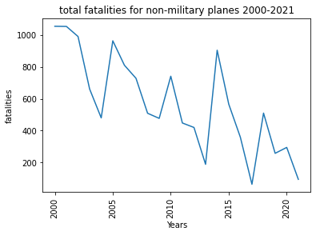

```python
mil = []
nonmil = []
years = []
for i in milDeaths:
  mil.append(i[0])
  years.append(i[1])
for i in nonMilDeaths:
  nonmil.append(i[0])


plt.plot(years, mil)
plt.xticks(rotation = 'vertical')
plt.title('total fatalities for military planes 2000-2021')
plt.xlabel('Years')
plt.ylabel('fatalities')
plt.show()

plt.plot(years, nonmil)
plt.xticks(rotation = 'vertical')
plt.title('total fatalities for non-military planes 2000-2021')
plt.xlabel('Years')
plt.ylabel('fatalities')
plt.show()
```

Based on the graphs, the fatalities for military deaths follow no trend. However, civilian fatalities seem to decrease over the years, this makes sense as the regulations we listed above seem to only affect commercial aircrafts. The reason for seperating planes between military and non-military is because when the average person thinks about plane accidents they are thinking about passenger planes or cargo planes. Military planes serve different purposes and it's not a type of plane that is accessible to everyone.

# Conclusion

After looking at different aspects of plane crashes, we think it is resonable to say planes have indeed gotten safer throughout the years. We can also see that technological improvements and new regulations have lead to fewer crashes as evidenced in the articles linked previously. Since we only have data of plane crashes, we don't get to see all the planes that don't crash but we can infer that on average air travel has increased due to globalization and the increasing wealth of middle class citizens in countries with emerging air travel markets.

When we took a look at the most fatalities for plane crashes, we see a lot of developing countries pop up such as Nigeria, Iran, Indonesia, and even Russia (considered a developing country by the IMF and UN). This is cause for concern for airline operators, as their numbers will only continue to grow as the air travel market expands bigger as the countries become more developed.

Lasty, there are still some factors that this analysis does not consider and there are also some limitations from the data we have analyzed. Some factors missing are the planes that don't crash, this would help in figuring out the likelyhood of these crashes given their factors compared to planes that don't crash with similar factors. There were also some limitations such as only looking at 2000-2021, maybe looking at previous years would help build an argument in the trends discussed. There was also some limitations in missing data which lead to assumptions which could affect our analysis.